# chap5_industry_applications

1 Logistic Regression Classification

1.1 data types

1.2 distribution of classes

1.3 split the data

1.4 Tfidf vectorizing xtrain and xvalid

1.5 Label encoding ytrain and yvalid

1.6 Logistic Regression (multiclass)

1.7 Accuracy

1.8 Classification report

1.9 Confusion matrix

1.10 Prediction example

2 Sentiment Analysis

2.1 Text preprocessing

2.2 EDA

2.2.1 Balance the dataset

2.3 word cloud

2.4 Sentiment scores

2.5 Business insights

3 Applying Text Similarity Functions

3.1 Deduplication in the same table

3.1.1 Load the data

3.1.2 Step 3A-2 Blocking

3.1.3 Step 3A-3 Similarity matching and scoring

3.1.4 Predicting records match or do not match using ECM – classifier

3.2 Records of same customers from multiple tables

3.2.1 Step 3B-2 Blocking – to reduce the comparison window and creating record pairs

3.2.2 Step 3B-3 Similarity matching

3.2.3 Step 3B-4 Predicting records match or do not match using ECM – classifier

4 Summarizing Text Data

4.1 TextRank

4.2 Feature-based text summarization

5 Clustering Documents

5.1 Load the data

5.2 Preprocessing and TF-IDF feature engineering

5.3 Clustering using K-means

5.4 Identify cluster behavior

5.5 Plot the clusters on a 2D graph

6 NLP in a Search Engine

**Implementing Industry Applications**

In this chapter, we are going to implement end-to-end solutions for a few of the Industry applications around NLP.

- Recipe 1. Consumer complaint classification
- Recipe 2. Customer reviews sentiment prediction
- Recipe 3. Data stitching using record linkage
- Recipe 4. Text summarization for subject notes
- Recipe 5. Document clustering
- Recipe 6. Search engine and learning to rank

Data: https://www.kaggle.com/subhassing/exploring-consumer-complaint-data/data

**Problem**  
Each week the Consumer Financial Protection Bureau sends thousands of consumers’ complaints about financial products and services to companies for a response. Classify those consumer complaints into the product category it belongs to using the description of the complaint.

**Solution**  
The goal of the project is to classify the complaint into a specific product category. Since it has multiple categories, it becomes a multiclass classification that can be solved through many of the machine learning algorithms.

Once the algorithm is in place, whenever there is a new complaint, we can easily categorize it and can then be redirected to the concerned person. This will save a lot of time because we are minimizing the human intervention to decide whom this complaint should go to.

**How It Works**  
Let’s explore the data and build classification problem using many machine learning algorithms and see which one gives better results.

```python
import numpy as np
import pandas as pd
import seaborn as sns
sns.set(color_codes=True)

import matplotlib
import matplotlib as mpl
import matplotlib.pyplot as plt
%matplotlib inline

print([(x.__name__,x.__version__) for x in [np, pd,sns,matplotlib]])
```

```
[('numpy', '1.17.1'), ('pandas', '0.25.1'), ('seaborn', '0.9.0'), ('matplotlib', '3.1.1')]
```

```python
# Jupyter notebook settings for pandas
pd.set_option('display.max_columns', None)
pd.set_option('display.float_format', '{:,.2f}'.format) # numbers sep by comma
pd.set_option('display.max_rows', 100) # None for all the rows
pd.set_option('display.max_colwidth', 500)
```

```python
import time
import os
import ast # literal_eval
import string
from io import StringIO
from tqdm import tqdm, tqdm_notebook
```

```python
from nltk.stem import SnowballStemmer
from nltk.corpus import stopwords
from nltk.stem import PorterStemmer

from textblob import TextBlob
from textblob import Word

import wordcloud
from wordcloud import WordCloud
```

```python
from sklearn.model_selection import train_test_split

from sklearn import feature_extraction
from sklearn.feature_extraction.text import TfidfVectorizer
from sklearn.feature_extraction.text import CountVectorizer
from sklearn.feature_extraction.text import TfidfVectorizer
import sklearn.feature_extraction.text as text

from sklearn import model_selection
from sklearn import preprocessing
from sklearn import linear_model, naive_bayes, svm

# classification_report
from sklearn import metrics # accuracy_score, confusion_matrix
from sklearn.metrics.pairwise import cosine_similarity

from sklearn.naive_bayes import MultinomialNB
from sklearn.linear_model import LogisticRegression
from sklearn.ensemble import RandomForestClassifier
from sklearn.svm import LinearSVC
from sklearn.model_selection import cross_val_score

from sklearn.manifold import MDS
```

```python
from vaderSentiment.vaderSentiment import SentimentIntensityAnalyzer
```

```python
import recordlinkage
recordlinkage.set_option('classification.return_type', 'series')

from recordlinkage.datasets import load_febrl1
from recordlinkage.datasets import load_febrl4
```

```python
from gensim.summarization.summarizer import summarize
from gensim.summarization import keywords
```

```python
from sumy.parsers.html import HtmlParser
from sumy.parsers.plaintext import PlaintextParser
from sumy.nlp.tokenizers import Tokenizer
from sumy.summarizers.lsa import LsaSummarizer
from sumy.nlp.stemmers import Stemmer
from sumy.utils import get_stop_words
from sumy.summarizers.luhn import LuhnSummarizer
```

```python
import mpld3
```

# Logistic Regression Classification

To increase the accuracy, we can do the following things:  
• Reiterate the process with different algorithms like Random Forest, SVM, GBM, Neural Networks, Naive Bayes.

• Deep learning techniques like RNN and LSTM (will be discussed in next chapter) can also be used. Chapter 5 Implementing Industry Applications

• In each of these algorithms, there are so many parameters to be tuned to get better results. It can be easily done through Grid search, which will basically try out all possible combinations and give the best out.

```python
!ls /Users/poudel/Datasets/kaggle/consumer_finance_complaints/
```

```
consumer_complaints.csv
```

```python
datdir = os.path.expanduser('~') + '/Datasets/kaggle/consumer_finance_complaints/'
fname = datdir + 'consumer_complaints.csv'

df = pd.read_csv(fname,encoding='latin-1',low_memory=False)
print(df.shape)

df.head().append(df.tail()).T
```

[output not shown]

```python
df.columns
```

```
Index(['date_received', 'product', 'sub_product', 'issue', 'sub_issue',
       'consumer_complaint_narrative', 'company_public_response', 'company',
       'state', 'zipcode', 'tags', 'consumer_consent_provided',
       'submitted_via', 'date_sent_to_company', 'company_response_to_consumer',
       'timely_response', 'consumer_disputed?', 'complaint_id'],
      dtype='object')
```

```python
# select data
df = df[['product','consumer_complaint_narrative']]
print(df.shape)
df = df.dropna(subset=['consumer_complaint_narrative'])

print(df.shape)
df.head()
```

```
(555957, 2)
(66806, 2)
```

|  | product | consumer_complaint_narrative |
| --- | --- | --- |
| 190126 | Debt collection | XXXX has claimed I owe them {$27.00} for XXXX ... |
| 190135 | Consumer Loan | Due to inconsistencies in the amount owed that... |
| 190155 | Mortgage | In XX/XX/XXXX my wages that I earned at my job... |
| 190207 | Mortgage | I have an open and current mortgage with Chase... |
| 190208 | Mortgage | XXXX was submitted XX/XX/XXXX. At the time I s... |

## data types

```python
df['product'] = df['product'].astype('category')
df['category_id'] = df['product'].factorize()[0] # use factorize, it reads from first row.
df['category_id2'] = df['product'].cat.codes # this gives different column

df.head()
```

|  | product | consumer_complaint_narrative | category_id | category_id2 |
| --- | --- | --- | --- | --- |
| 190126 | Debt collection | XXXX has claimed I owe them {$27.00} for XXXX ... | 0 | 4 |
| 190135 | Consumer Loan | Due to inconsistencies in the amount owed that... | 1 | 1 |
| 190155 | Mortgage | In XX/XX/XXXX my wages that I earned at my job... | 2 | 6 |
| 190207 | Mortgage | I have an open and current mortgage with Chase... | 2 | 6 |
| 190208 | Mortgage | XXXX was submitted XX/XX/XXXX. At the time I s... | 2 | 6 |

## distribution of classes

```python
# df.groupby('product')['consumer_complaint_narrative'].count()
```

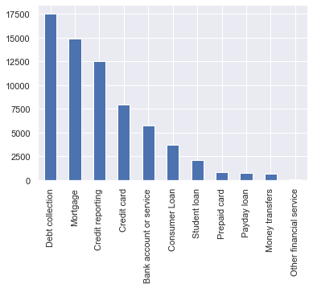

```python
df['product'].value_counts().plot.bar()
```

## split the data

```python
from sklearn.model_selection import train_test_split
```

```python
Xtrain, Xvalid, ytrain, yvalid = train_test_split(df.consumer_complaint_narrative, df['product'], random_state=0)

Xtrain.shape, Xvalid.shape
```

```
((50104,), (16702,))
```

## Tfidf vectorizing xtrain and xvalid

```python
from sklearn.feature_extraction.text import TfidfVectorizer
```

```python
vec = TfidfVectorizer(analyzer='word',
                     token_pattern=r'\w{1,}',
                     max_features=5000)
```

```python
# fit using all data
vec.fit(df['consumer_complaint_narrative'])
```

```
TfidfVectorizer(analyzer='word', binary=False, decode_error='strict',
                dtype=<class 'numpy.float64'>, encoding='utf-8',
                input='content', lowercase=True, max_df=1.0, max_features=5000,
                min_df=1, ngram_range=(1, 1), norm='l2', preprocessor=None,
                smooth_idf=True, stop_words=None, strip_accents=None,
                sublinear_tf=False, token_pattern='\\w{1,}', tokenizer=None,
                use_idf=True, vocabulary=None)
```

```python
Xtrain_tfidf = vec.transform(Xtrain)
Xvalid_tfidf = vec.transform(Xvalid)
```

## Label encoding ytrain and yvalid

```python
from sklearn import preprocessing
```

```python
le = preprocessing.LabelEncoder()
```

```python
ytrain = le.fit_transform(ytrain)
yvalid = le.fit_transform(yvalid)
```

## Logistic Regression (multiclass)

```python
from sklearn import linear_model
```

```python
logreg = linear_model.LogisticRegression(solver='lbfgs',
                                         random_state=0,
                                        max_iter=1000)
```

```python
model = logreg.fit(Xtrain_tfidf, ytrain)
```

```python
model
```

```
LogisticRegression(C=1.0, class_weight=None, dual=False, fit_intercept=True,
                   intercept_scaling=1, l1_ratio=None, max_iter=1000,
                   multi_class='warn', n_jobs=None, penalty='l2',
                   random_state=0, solver='lbfgs', tol=0.0001, verbose=0,
                   warm_start=False)
```

## Accuracy

```python
from sklearn.metrics import accuracy_score
```

```python
acc = accuracy_score(model.predict(Xvalid_tfidf), yvalid)
acc
```

```
0.8439707819422824
```

## Classification report

```python
from sklearn import metrics
```

```python
ypreds = model.predict(Xvalid_tfidf)

report = metrics.classification_report(yvalid, ypreds, target_names = df['product'].unique())
print(report)
```

[output not shown]

## Confusion matrix

```python
cm = metrics.confusion_matrix(yvalid, ypreds)
cm
```

```
array([[1172,    8,  136,   33,   36,    8,   63,    0,    1,   33,    0],
       [  24,  537,   69,   77,  160,    0,   75,    0,    7,    1,    4],
       [  63,    9, 1626,  125,  154,    4,   20,    0,    0,    2,    0],
       [   6,   27,   62, 2577,  273,    0,   58,    0,    3,    0,    4],
       [  25,   41,   78,  188, 3925,    2,   84,    0,   12,    0,   30],
       [  39,    2,   14,    6,   15,   83,   10,    0,    0,    2,    0],
       [  28,   11,   15,   53,   57,    0, 3591,    0,    0,    0,    1],
       [   4,    0,    2,    1,    7,    4,    3,    0,    0,    0,    0],
       [  14,   20,    7,    4,   74,    0,   10,    0,   32,    0,    0],
       [  23,    1,   39,    1,   12,    1,    1,    0,    0,  127,    0],
       [   4,    4,    7,   11,   66,    0,   28,    0,    0,    0,  426]])
```

```python
df_cm = pd.DataFrame(cm, columns=df['product'].unique(),index=df['product'].unique())
df_cm.style.background_gradient(cmap="BuPu")
```

[output not shown]

[figure not shown]

```python
fig, ax = plt.subplots(figsize=(12,8))

sns.heatmap(cm, annot=True, fmt='d', cmap="BuPu",
            xticklabels=df['product'].unique(),
            yticklabels=df['product'].unique())
plt.ylabel('Actual')
plt.xlabel('Predicted')
```

## Prediction example

```python
texts = ["This company refuses to provide me verification"\
         "and validation of debt per my right under the FDCPA."\
         "I do not believe this debt is mine."]

text_features = vec.transform(texts)

predictions = model.predict(text_features)
```

[output not shown]

```python
category_id_df = df[['product', 'category_id']].drop_duplicates().sort_values('category_id')
category_id_df.head()
```

|  | product | category_id |
| --- | --- | --- |
| 190126 | Debt collection | 0 |
| 190135 | Consumer Loan | 1 |
| 190155 | Mortgage | 2 |
| 190263 | Credit card | 3 |
| 191477 | Credit reporting | 4 |

```python
category_to_id = dict(category_id_df.values)
id_to_category = dict(category_id_df[['category_id', 'product']].values)
```

```python
print(" - Predicted as: '{}'".format(id_to_category[predictions[0]]))
```

[output not shown]

```python
predictions
```

```
array([4])
```

# Sentiment Analysis

Data: https://www.kaggle.com/snap/amazon-fine-food-reviews

```python
datdir = os.path.expanduser('~') + '/Datasets/kaggle/amazon_fine_food_reviews/'
fname = datdir + 'reviews.csv'

df = pd.read_csv(fname,encoding='latin-1',low_memory=False)
print(df.shape)

df.head(2).append(df.tail(2)).T
```

```
(568454, 10)
```

|  | 0 | 1 | 568452 | 568453 |
| --- | --- | --- | --- | --- |
| Id | 1 | 2 | 568453 | 568454 |
| ProductId | B001E4KFG0 | B00813GRG4 | B004I613EE | B001LR2CU2 |
| UserId | A3SGXH7AUHU8GW | A1D87F6ZCVE5NK | A3IBEVCTXKNOH | A3LGQPJCZVL9UC |
| ProfileName | delmartian | dll pa | Kathy A. Welch "katwel" | srfell17 |
| HelpfulnessNumerator | 1 | 0 | 1 | 0 |
| HelpfulnessDenominator | 1 | 0 | 1 | 0 |
| Score | 5 | 1 | 5 | 5 |
| Time | 1303862400 | 1346976000 | 1331596800 | 1338422400 |
| Summary | Good Quality Dog Food | Not as Advertised | Favorite Training and reward treat | Great Honey |
| Text | I have bought several of the Vitality canned dog food products and have found them all to be of good quality. The product looks more like a stew than a processed meat and it smells better. My Labrador… | Product arrived labeled as Jumbo Salted Peanuts...the peanuts were actually small sized unsalted. Not sure if this was an error or if the vendor intended to represent the product as "Jumbo". | These are the BEST treats for training and rewarding your dog for being good while grooming. Lower in calories and loved by all the doggies. Sweet potatoes seem to be their favorite Wet Noses treat! | I am very satisfied ,product is as advertised, I use it on cereal, with raw vinegar, and as a general sweetner. |

```python
df.info()
```

```
<class 'pandas.core.frame.DataFrame'>
RangeIndex: 568454 entries, 0 to 568453
Data columns (total 10 columns):
Id                        568454 non-null int64
ProductId                 568454 non-null object
UserId                    568454 non-null object
ProfileName               568438 non-null object
HelpfulnessNumerator      568454 non-null int64
HelpfulnessDenominator    568454 non-null int64
Score                     568454 non-null int64
Time                      568454 non-null int64
Summary                   568427 non-null object
Text                      568454 non-null object
dtypes: int64(5), object(5)
memory usage: 43.4+ MB
```

## Text preprocessing

```python
from nltk.corpus import stopwords
from textblob import TextBlob
from textblob import Word
```

```python
# Lower casing and removing punctuations
df['Text'] = df['Text'].apply(lambda x: " ".join(x.lower() for x in x.split()))

df['Text'] = df['Text'].str.replace('[^\w\s]',"")
df.Text.head(5)
```

```
0                                                                                                                                                                                                                                       i have bought several of the vitality canned dog food products and h…
1                                                                                                                                                                                                                                                                                                           …
2    this is a confection that has been around a few centuries it is a light pillowy citrus gelatin with nuts  in this case filberts and it is cut into tiny squares and then liberally coated with powdered sugar and it is a tiny mouthful of heaven not too chewy and very flavorful i highly recommend t…
3                                                                                                                                                                                                                                                                                      if you are looking fo…
4                                                                                                                                                                                                                                                                                                           …
Name: Text, dtype: object
```

```python
# Removal of stop words
stop = stopwords.words('english')
df['Text'] = df['Text'].apply(lambda x: " ".join(x for x in x.split() if x not in stop))
df.Text.head(5)
```

```
0                                                                                                                             bought several vitality canned dog food products found good quality product looks like stew processed meat smells better labrador finicky appreciates product better
1                                                                                                                                                         product arrived labeled jumbo salted peanutsthe peanuts actually small sized unsalted sure error vendor intended represent product jumbo
2    confection around centuries light pillowy citrus gelatin nuts case filberts cut tiny squares liberally coated powdered sugar tiny mouthful heaven chewy flavorful highly recommend yummy treat familiar story cs lewis lion witch wardrobe treat seduces edmund selling brother sisters witch
3                                                                                                                                                                 looking secret ingredient robitussin believe found got addition root beer extract ordered good made cherry soda flavor medicinal
4                                                                                                                                                                                                              great taffy great price wide assortment yummy taffy delivery quick taffy lover deal
Name: Text, dtype: object
```

```python
# Spelling correction
from textblob import TextBlob
from tqdm import tqdm, tqdm_notebook
import time
tqdm_notebook().pandas()
```

```python
t0 = time.time()
# df['Text'] = df['Text'].progress_apply(lambda x: str(TextBlob(x).correct()))

t1 = time.time() - t0
print('Time taken: {:.0f} min {:.0f} secs'.format(*divmod(t1,60)))
# df.Text.head(5)
```

```
Time taken: 0 min 0 secs
```

```python
# Lemmatization
from textblob import Word
# df['Text'] = df['Text'].progress_apply(lambda x: " ".join([Word(word).lemmatize() for word in x.split()]))
# df.Text.head(5)
```

## EDA

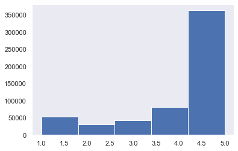

```
Score
1     52264
2     29743
3     42638
4     80655
5    363111
Name: Id, dtype: int64
```

```python
reviews = df.copy()

# Dropping null values
reviews.dropna(inplace=True)

# The histogram reveals this dataset is highly unbalanced towards high rating.
reviews.Score.hist(bins=5,grid=False)
plt.show()
print(reviews.groupby('Score').count().Id)
```

```python
reviews.Score.value_counts()
```

```
5    363111
4     80655
1     52264
3     42638
2     29743
Name: Score, dtype: int64
```

### Balance the dataset

```python
reviews.head()
```

|  | Id | ProductId | UserId | ProfileName | HelpfulnessNumerator | HelpfulnessDenominator | Score | Time | Summary | Text |
| --- | --- | --- | --- | --- | --- | --- | --- | --- | --- | --- |
| 0 | 1 | B001E4KFG0 | A3SGXH7AUHU8GW | delmartian | 1 | 1 | 5 | 1303862400 | Good Quality Dog Food | bought several vitality canned dog food products found good quality product looks like stew processed meat smells better labrador finicky appreciates product better |
| 1 | 2 | B00813GRG4 | A1D87F6ZCVE5NK | dll pa | 0 | 0 | 1 | 1346976000 | Not as Advertised | product arrived labeled jumbo salted peanutsthe peanuts actually small sized unsalted sure error vendor intended represent product jumbo |
| 2 | 3 | B000LQOCH0 | ABXLMWJIXXAIN | Natalia Corres "Natalia Corres" | 1 | 1 | 4 | 1219017600 | "Delight" says it all | confection around centuries light pillowy citrus gelatin nuts case filberts cut tiny squares liberally coated powdered sugar tiny mouthful heaven chewy flavorful highly recommend yummy treat familiar … |
| 3 | 4 | B000UA0QIQ | A395BORC6FGVXV | Karl | 3 | 3 | 2 | 1307923200 | Cough Medicine | looking secret ingredient robitussin believe found got addition root beer extract ordered good made cherry soda flavor medicinal |
| 4 | 5 | B006K2ZZ7K | A1UQRSCLF8GW1T | Michael D. Bigham "M. Wassir" | 0 | 0 | 5 | 1350777600 | Great taffy | great taffy great price wide assortment yummy taffy delivery quick taffy lover deal |

```python
reviews.Score.value_counts()
```

```
5    363111
4     80655
1     52264
3     42638
2     29743
Name: Score, dtype: int64
```

```python
n = reviews.Score.value_counts().values[-1]
reviews_sample = reviews.groupby('Score').apply(lambda x: x.sample(n)).reset_index(drop=True)

reviews_sample.Score.value_counts()
```

```
5    29743
4    29743
3    29743
2    29743
1    29743
Name: Score, dtype: int64
```

```python
reviews_sample['target'] = pd.cut(reviews_sample.Score,
                                  [0,2,3,np.nan],
                                  labels=['negative','neutral','positive'])

reviews_sample[['Score','target']].sample(10)
```

|  | Score | target |
| --- | --- | --- |
| 147285 | 5 | positive |
| 145613 | 5 | positive |
| 134981 | 5 | positive |
| 81068 | 3 | neutral |
| 120833 | 5 | positive |
| 15470 | 1 | negative |
| 141044 | 5 | positive |
| 125069 | 5 | positive |
| 44048 | 2 | negative |
| 141926 | 5 | positive |

## word cloud

```python
import wordcloud
```

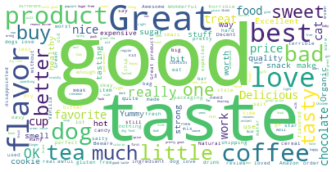

```python
# Wordcloud function's input needs to be a single string of text.
# Here I'm concatenating all Summaries into a single string.
# similarly you can build for Text column

def plot_wordcloud(text_str):
    wordcloud = WordCloud(background_color='white').generate(reviews_str)
    plt.figure(figsize=(10,10))
    plt.imshow(wordcloud,interpolation='bilinear')
    plt.axis("off")
    plt.show()

reviews_str = reviews_sample.Summary.str.cat()
plot_wordcloud(reviews_str)
```

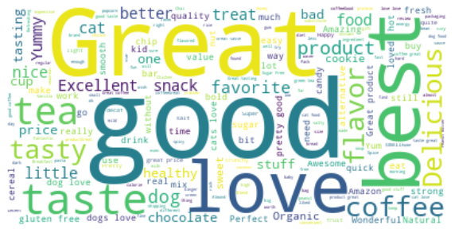

```python
reviews_str = reviews_sample.query('Score > 3').Summary.str.cat()
plot_wordcloud(reviews_str)
```

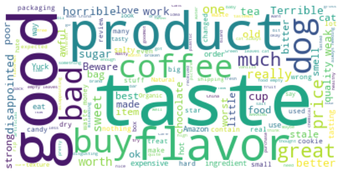

```python
reviews_str = reviews_sample.query('Score < 3').Summary.str.cat()
plot_wordcloud(reviews_str)
```

## Sentiment scores

```python
import ast
import seaborn as sns
sns.set(color_codes=True)

cp = sns.color_palette()
plt.style.use('fivethirtyeight')
```

```python
from vaderSentiment.vaderSentiment import SentimentIntensityAnalyzer
analyzer = SentimentIntensityAnalyzer()
```

```python
emptyline=[]
for row in tqdm(df['Text']):
    vs=analyzer.polarity_scores(row)
    emptyline.append(vs)
```

```python
# Creating new dataframe with sentiments
df_sentiments=pd.DataFrame(emptyline)
df_sentiments.head(5)
```

|  | neg | neu | pos | compound |
| --- | --- | --- | --- | --- |
| 0 | 0.00 | 0.50 | 0.50 | 0.94 |
| 1 | 0.13 | 0.76 | 0.11 | -0.10 |
| 2 | 0.17 | 0.55 | 0.28 | 0.81 |
| 3 | 0.00 | 0.85 | 0.15 | 0.44 |
| 4 | 0.00 | 0.37 | 0.63 | 0.95 |

```python
# Merging the sentiments back to reviews dataframe
df_c = pd.concat([df.reset_index(drop=True), df_sentiments], axis=1)
df_c.head(3)
```

|  | Id | ProductId | UserId | ProfileName | HelpfulnessNumerator | HelpfulnessDenominator | Score | Time | Summary | Text | neg | neu | pos | compound |
| --- | --- | --- | --- | --- | --- | --- | --- | --- | --- | --- | --- | --- | --- | --- |
| 0 | 1 | B001E4KFG0 | A3SGXH7AUHU8GW | delmartian | 1 | 1 | 5 | 1303862400 | Good Quality Dog Food | bought several vitality canned dog food products found good quality product looks like stew processed meat smells better labrador finicky appreciates product better | 0.00 | 0.50 | 0.50 | 0.94 |
| 1 | 2 | B00813GRG4 | A1D87F6ZCVE5NK | dll pa | 0 | 0 | 1 | 1346976000 | Not as Advertised | product arrived labeled jumbo salted peanutsthe peanuts actually small sized unsalted sure error vendor intended represent product jumbo | 0.13 | 0.76 | 0.11 | -0.10 |
| 2 | 3 | B000LQOCH0 | ABXLMWJIXXAIN | Natalia Corres "Natalia Corres" | 1 | 1 | 4 | 1219017600 | "Delight" says it all | confection around centuries light pillowy citrus gelatin nuts case filberts cut tiny squares liberally coated powdered sugar tiny mouthful heaven chewy flavorful highly recommend yummy treat familiar … | 0.17 | 0.55 | 0.28 | 0.81 |

```python
# Convert scores into positive and negetive sentiments using some threshold
df_c['Sentiment'] = np.where(df_c['compound'] >= 0 , 'Positive', 'Negative')
df_c.head(5)
```

|  | Id | ProductId | UserId | ProfileName | HelpfulnessNumerator | HelpfulnessDenominator | Score | Time | Summary | Text | neg | neu | pos | compound | Sentiment |
| --- | --- | --- | --- | --- | --- | --- | --- | --- | --- | --- | --- | --- | --- | --- | --- |
| 0 | 1 | B001E4KFG0 | A3SGXH7AUHU8GW | delmartian | 1 | 1 | 5 | 1303862400 | Good Quality Dog Food | bought several vitality canned dog food products found good quality product looks like stew processed meat smells better labrador finicky appreciates product better | 0.00 | 0.50 | 0.50 | 0.94 | Positive |
| 1 | 2 | B00813GRG4 | A1D87F6ZCVE5NK | dll pa | 0 | 0 | 1 | 1346976000 | Not as Advertised | product arrived labeled jumbo salted peanutsthe peanuts actually small sized unsalted sure error vendor intended represent product jumbo | 0.13 | 0.76 | 0.11 | -0.10 | Negative |
| 2 | 3 | B000LQOCH0 | ABXLMWJIXXAIN | Natalia Corres "Natalia Corres" | 1 | 1 | 4 | 1219017600 | "Delight" says it all | confection around centuries light pillowy citrus gelatin nuts case filberts cut tiny squares liberally coated powdered sugar tiny mouthful heaven chewy flavorful highly recommend yummy treat familiar … | 0.17 | 0.55 | 0.28 | 0.81 | Positive |
| 3 | 4 | B000UA0QIQ | A395BORC6FGVXV | Karl | 3 | 3 | 2 | 1307923200 | Cough Medicine | looking secret ingredient robitussin believe found got addition root beer extract ordered good made cherry soda flavor medicinal | 0.00 | 0.85 | 0.15 | 0.44 | Positive |
| 4 | 5 | B006K2ZZ7K | A1UQRSCLF8GW1T | Michael D. Bigham "M. Wassir" | 0 | 0 | 5 | 1350777600 | Great taffy | great taffy great price wide assortment yummy taffy delivery quick taffy lover deal | 0.00 | 0.37 | 0.63 | 0.95 | Positive |

## Business insights

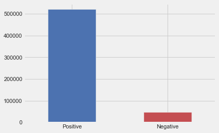

```python
result=df_c['Sentiment'].value_counts()
result.plot(kind='bar', rot=0,color=list('br'));
```

```python
result=df_c.groupby('ProductId')['Sentiment'].value_counts().unstack()

result.head()
```

| Sentiment ProductId | Negative | Positive |
| --- | --- | --- |
| 0006641040 | 1.00 | 36.00 |
| 141278509X | nan | 1.00 |
| 2734888454 | nan | 2.00 |
| 2841233731 | nan | 1.00 |
| 7310172001 | 5.00 | 168.00 |

# Applying Text Similarity Functions

**Problem**  
We will have multiple tables in the database, and sometimes there won’t be a common “ID” or “KEY” to join them – scenarios like the following:

- • Customer information scattered across multiple tables and systems.
- • No global key to link them all together.
- • A lot of variations in names and addresses.

Solution

This can be solved by applying text similarity functions on the demographic’s columns like the first name, last name, address, etc. And based on the similarity score on a few common columns, we can decide either the record pair is a match or not a match.

How It Works

Let’s follow the steps in this section to link the records. Technical challenge:

- • Huge records that need to be linked/stitched/ deduplicated.
- • Records come from various systems with differing schemas.

There is no global key or customer id to merge. There are two possible scenarios of data stitching or linking records:

- • Multiple records of the same customer at the same table, and you want to dedupe.
- • Records of same customers from multiple tables need to be merged.

## Deduplication in the same table

### Load the data

```python
import recordlinkage
from recordlinkage.datasets import load_febrl1
```

```python
dfA = load_febrl1()

print(dfA.shape)
dfA.head()
```

```
(1000, 10)
```

| rec_id | given_name | surname | street_number | address_1 | address_2 | suburb | postcode | state | date_of_birth | soc_sec_id |
| --- | --- | --- | --- | --- | --- | --- | --- | --- | --- | --- |
| rec-223-org | NaN | waller | 6 | tullaroop street | willaroo | st james | 4011 | wa | 19081209 | 6988048 |
| rec-122-org | lachlan | berry | 69 | giblin street | killarney | bittern | 4814 | qld | 19990219 | 7364009 |
| rec-373-org | deakin | sondergeld | 48 | goldfinch circuit | kooltuo | canterbury | 2776 | vic | 19600210 | 2635962 |
| rec-10-dup-0 | kayla | harrington | NaN | maltby circuit | coaling | coolaroo | 3465 | nsw | 19150612 | 9004242 |
| rec-227-org | luke | purdon | 23 | ramsay place | mirani | garbutt | 2260 | vic | 19831024 | 8099933 |

### Step 3A-2 Blocking

Here we reduce the comparison window and create record pairs. Why?

- • Suppose there are huge records say, 100M records means (100M choose 2) ≈ 10^16 possible pairs
- • Need heuristic to quickly cut that 10^16 down without losing many matches This can be accomplished by extracting a “blocking key” How? Example:
- • Record: first name: John, last name: Roberts, address: 20 Main St Plainville MA 01111
- • Blocking key: first name - John
- • Will be paired with: John Ray … 011
- • Won’t be paired with: Frank Sinatra … 07030
- • Generate pairs only for records in the same block

Below is the blocking example at a glance: here blocking is done on the “Sndx-SN,” column which is nothing but the Soundex value of the surname column as discussed in the previous chapter.

There are many advanced blocking techniques, also, like the following:

- • Standard blocking
- • Single column
- • Multiple columns
- • Sorted neighborhood
- • Q-gram: fuzzy blocking
- • LSH
- • Canopy clustering

This can be a new topic altogether, but for now, let’s build the pairs using the first name as the blocking index.

[figure not shown]

```python
indexer = recordlinkage.index.Block(left_on='given_name')
pairs = indexer.index(dfA)
print (len(pairs))

pairs[0]
```

```
2082
```

```
('rec-183-dup-0', 'rec-122-org')
```

```python
print(dfA.shape)
dfA.head(1)
```

```
(1000, 10)
```

| rec_id | given_name | surname | street_number | address_1 | address_2 | suburb | postcode | state | date_of_birth | soc_sec_id |
| --- | --- | --- | --- | --- | --- | --- | --- | --- | --- | --- |
| rec-223-org | NaN | waller | 6 | tullaroop street | willaroo | st james | 4011 | wa | 19081209 | 6988048 |

### Step 3A-3 Similarity matching and scoring

Here we compute the similarity scores on the columns like given name, surname, and address between the record pairs generated in the previous step. For columns like date of birth, suburb, and state, we are using the exact match as it is important for this column to possess exact records. We are using jarowinkler, but you can use any of the other similarity measures discussed in Chapter 4.

```python
dfA.head(2)
```

| rec_id | given_name | surname | street_number | address_1 | address_2 | suburb | postcode | state | date_of_birth | soc_sec_id |
| --- | --- | --- | --- | --- | --- | --- | --- | --- | --- | --- |
| rec-223-org | NaN | waller | 6 | tullaroop street | willaroo | st james | 4011 | wa | 19081209 | 6988048 |
| rec-122-org | lachlan | berry | 69 | giblin street | killarney | bittern | 4814 | qld | 19990219 | 7364009 |

```python
import recordlinkage
recordlinkage.set_option('classification.return_type', 'series')

indexer = recordlinkage.index.Block(left_on='given_name')
pairs = indexer.index(dfA)
print('len pairs = ', len(pairs))
print('dfA shape = ', dfA.shape)
print(pairs[0], pairs[-1])

compare_cl = recordlinkage.Compare()

compare_cl.string('given_name', 'given_name',method='jarowinkler',label='given_name')
compare_cl.string('surname', 'surname',method='jarowinkler',label='surname')
compare_cl.string('address_1', 'address_1',method='jarowinkler',label='address_1')

compare_cl.exact('suburb', 'suburb', label='suburb')
compare_cl.exact('state', 'state', label='state')
compare_cl.exact('date_of_birth', 'date_of_birth',label='date_of_birth')


features = compare_cl.compute(pairs, dfA)
features.head()
```

```
len pairs =  2082
dfA shape =  (1000, 10)
('rec-183-dup-0', 'rec-122-org') ('rec-327-org', 'rec-411-org')
```

| rec_id_1 | rec_id_2 | given_name | surname | address_1 | suburb | state | date_of_birth |
| --- | --- | --- | --- | --- | --- | --- | --- |
| rec-183-dup-0 | rec-122-org | 1.00 | 0.00 | 0.63 | 0 | 0 | 0 |
| rec-248-org | rec-122-org | 1.00 | 0.60 | 0.64 | 0 | 1 | 0 |
|  | rec-183-dup-0 | 1.00 | 0.47 | 0.82 | 0 | 0 | 0 |
| rec-122-dup-0 | rec-122-org | 1.00 | 1.00 | 1.00 | 1 | 1 | 1 |
|  | rec-183-dup-0 | 1.00 | 0.00 | 0.63 | 0 | 0 | 0 |

```python
dfA.head(2)
```

| rec_id | given_name | surname | street_number | address_1 | address_2 | suburb | postcode | state | date_of_birth | soc_sec_id |
| --- | --- | --- | --- | --- | --- | --- | --- | --- | --- | --- |
| rec-223-org | NaN | waller | 6 | tullaroop street | willaroo | st james | 4011 | wa | 19081209 | 6988048 |
| rec-122-org | lachlan | berry | 69 | giblin street | killarney | bittern | 4814 | qld | 19990219 | 7364009 |

### Predicting records match or do not match using ECM – classifier

```python
# select all the features except for given_name since its our blocking key
features1 = features[['suburb','state','surname','date_of_birth','address_1']]

# Unsupervised learning – probabilistic
ecm = recordlinkage.ECMClassifier()
result_ecm = ecm.fit_predict((features1).astype(int))

result_ecm
```

```
rec_id_1       rec_id_2
rec-183-dup-0  rec-122-org      0
rec-248-org    rec-122-org      0
               rec-183-dup-0    0
rec-122-dup-0  rec-122-org      1
               rec-183-dup-0    0
                               ..
rec-252-org    rec-252-dup-0    1
rec-48-dup-0   rec-48-org       1
rec-298-dup-0  rec-298-org      1
rec-282-org    rec-282-dup-0    1
rec-327-org    rec-411-org      0
Name: classification, Length: 2082, dtype: int64
```

## Records of same customers from multiple tables

```python
from recordlinkage.datasets import load_febrl4

dfA, dfB = load_febrl4()
dfA.head()
```

| rec_id | given_name | surname | street_number | address_1 | address_2 | suburb | postcode | state | date_of_birth | soc_sec_id |
| --- | --- | --- | --- | --- | --- | --- | --- | --- | --- | --- |
| rec-1070-org | michaela | neumann | 8 | stanley street | miami | winston hills | 4223 | nsw | 19151111 | 5304218 |
| rec-1016-org | courtney | painter | 12 | pinkerton circuit | bega flats | richlands | 4560 | vic | 19161214 | 4066625 |
| rec-4405-org | charles | green | 38 | salkauskas crescent | kela | dapto | 4566 | nsw | 19480930 | 4365168 |
| rec-1288-org | vanessa | parr | 905 | macquoid place | broadbridge manor | south grafton | 2135 | sa | 19951119 | 9239102 |
| rec-3585-org | mikayla | malloney | 37 | randwick road | avalind | hoppers crossing | 4552 | vic | 19860208 | 7207688 |

```python
dfB.head()
```

| rec_id | given_name | surname | street_number | address_1 | address_2 | suburb | postcode | state | date_of_birth | soc_sec_id |
| --- | --- | --- | --- | --- | --- | --- | --- | --- | --- | --- |
| rec-561-dup-0 | elton | NaN | 3 | light setreet | pinehill | windermere | 3212 | vic | 19651013 | 1551941 |
| rec-2642-dup-0 | mitchell | maxon | 47 | edkins street | lochaoair | north ryde | 3355 | nsw | 19390212 | 8859999 |
| rec-608-dup-0 | NaN | white | 72 | lambrigg street | kelgoola | broadbeach waters | 3159 | vic | 19620216 | 9731855 |
| rec-3239-dup-0 | elk i | menzies | 1 | lyster place | NaN | northwood | 2585 | vic | 19980624 | 4970481 |
| rec-2886-dup-0 | NaN | garanggar | NaN | may maxwell crescent | springettst arcade | forest hill | 2342 | vic | 19921016 | 1366884 |

### Step 3B-2 Blocking – to reduce the comparison window and creating record pairs

```python
indexer = recordlinkage.index.Block(left_on='given_name')
pairs = indexer.index(dfA, dfB)
```

### Step 3B-3 Similarity matching

```python
compare_cl = recordlinkage.Compare()

compare_cl.string('given_name', 'given_name',method='jarowinkler',label='given_name')
compare_cl.string('surname', 'surname', method='jarowinkler',label='surname')
compare_cl.string('address_1', 'address_1',method='jarowinkler',label='address_1')

compare_cl.exact('date_of_birth', 'date_of_birth', label='date_of_birth')
compare_cl.exact('suburb', 'suburb', label='suburb')
compare_cl.exact('state', 'state', label='state')


features = compare_cl.compute(pairs, dfA, dfB)
features.head(10)
```

| rec_id_1 | rec_id_2 | given_name | surname | address_1 | date_of_birth | suburb | state |
| --- | --- | --- | --- | --- | --- | --- | --- |
| rec-1070-org | rec-3024-dup-0 | 1.00 | 0.44 | 0.00 | 0 | 0 | 1 |
|  | rec-2371-dup-0 | 1.00 | 0.49 | 0.72 | 0 | 0 | 0 |
|  | rec-4652-dup-0 | 1.00 | 0.49 | 0.65 | 0 | 0 | 0 |
|  | rec-4795-dup-0 | 1.00 | 0.00 | 0.55 | 0 | 0 | 1 |
|  | rec-1314-dup-0 | 1.00 | 0.00 | 0.62 | 0 | 0 | 1 |
| rec-2371-org | rec-3024-dup-0 | 1.00 | 0.53 | 0.00 | 0 | 0 | 0 |
|  | rec-2371-dup-0 | 1.00 | 1.00 | 1.00 | 1 | 1 | 1 |
|  | rec-4652-dup-0 | 1.00 | 0.50 | 0.64 | 0 | 0 | 1 |
|  | rec-4795-dup-0 | 1.00 | 0.53 | 0.41 | 0 | 0 | 0 |
|  | rec-1314-dup-0 | 1.00 | 0.53 | 0.67 | 0 | 0 | 0 |

```python
dfA.head()
```

| rec_id | given_name | surname | street_number | address_1 | address_2 | suburb | postcode | state | date_of_birth | soc_sec_id |
| --- | --- | --- | --- | --- | --- | --- | --- | --- | --- | --- |
| rec-1070-org | michaela | neumann | 8 | stanley street | miami | winston hills | 4223 | nsw | 19151111 | 5304218 |
| rec-1016-org | courtney | painter | 12 | pinkerton circuit | bega flats | richlands | 4560 | vic | 19161214 | 4066625 |
| rec-4405-org | charles | green | 38 | salkauskas crescent | kela | dapto | 4566 | nsw | 19480930 | 4365168 |
| rec-1288-org | vanessa | parr | 905 | macquoid place | broadbridge manor | south grafton | 2135 | sa | 19951119 | 9239102 |
| rec-3585-org | mikayla | malloney | 37 | randwick road | avalind | hoppers crossing | 4552 | vic | 19860208 | 7207688 |

So here record “rec-1070-org” is compared with “rec-3024-dup-0,” “rec-2371-dup-0,” “rec-4652-dup-0,” “rec-4795-dup-0,” and “rec-1314- dup-0, since their first name (blocking column) is matching and similarity scores are calculated on the common columns for these pairs.

### Step 3B-4 Predicting records match or do not match using ECM – classifier

```python
# select all the features except for given_name since its our blocking key
features1 = features[['suburb','state','surname','date_of_birth', 'address_1']]

# unsupervised learning - probablistic
ecm = recordlinkage.ECMClassifier()
result_ecm = ecm.fit_predict((features1).astype(int))

result_ecm
```

```
rec_id_1      rec_id_2
rec-1070-org  rec-3024-dup-0    0
              rec-2371-dup-0    0
              rec-4652-dup-0    0
              rec-4795-dup-0    0
              rec-1314-dup-0    0
                               ..
rec-4528-org  rec-4528-dup-0    1
rec-4887-org  rec-4887-dup-0    1
rec-4350-org  rec-4350-dup-0    1
rec-4569-org  rec-4569-dup-0    1
rec-3125-org  rec-3125-dup-0    1
Name: classification, Length: 77249, dtype: int64
```

# Summarizing Text Data

Text summarization is the process of making large documents into smaller ones without losing the context, which eventually saves readers time. This can be done using different techniques like the following:

- • TextRank: A graph-based ranking algorithm
- • Feature-based text summarization
- • LexRank: TF-IDF with a graph-based algorithm
- • Topic based
- • Using sentence embeddings
- • Encoder-Decoder Model: Deep learning techniques

## TextRank

TextRank is the graph-based ranking algorithm for NLP. It is basically inspired by PageRank, which is used in the Google search engine but particularly designed for text. It will extract the topics, create nodes out of them, and capture the relation between nodes to summarize the text. Let’s see how to do it using the Python package Gensim. “Summarize” is the function used. Before that, let’s import the notes. Let’s say your article is Wikipedia for the topic of Natural language processing.

```python
from bs4 import BeautifulSoup
from urllib.request import urlopen
```

```python
from gensim.summarization.summarizer import summarize
from gensim.summarization import keywords
```

```python
def get_only_text(url):
    page = urlopen(url)
    soup = BeautifulSoup(page)
    text = ' '.join(map(lambda p: p.text, soup.find_all('p')))
    return soup.title.text, text
```

```python
url="https://en.wikipedia.org/wiki/Natural_language_processing"
title, text = get_only_text(url)
```

```python
print(len(text))
print(text[:1000])
```

```
8669
Natural language processing (NLP) is a subfield of linguistics, computer science, information engineering, and artificial intelligence concerned with the interactions between computers and human (natural) languages, in particular how to program computers to process and analyze large amounts of natur…
 Challenges in natural language processing frequently involve speech recognition, natural language understanding, and natural language generation.
 The history of natural language processing (NLP) generally started in the 1950s, although work can be found from earlier periods.
In 1950, Alan Turing published an article titled "Computing Machinery and Intelligence" which proposed what is now called the Turing test as a criterion of intelligence.
 The Georgetown experiment in 1954 involved fully automatic translation of more than sixty Russian sentences into English. The authors claimed that within three or five years, machine translation would be a solved problem.[2]  However
```

```python
# Convert text to string format
text = str(text)
```

[output not shown]

```python
#Summarize the text with ratio 0.1 (10% of the total words.)
summarize(text, ratio=0.1)
```

```
"This was due to both the steady increase in computational power (see Moore's law) and the gradual lessening of the dominance of Chomskyan theories of linguistics (e.g. transformational grammar), whose theoretical underpinnings discouraged the sort of corpus linguistics that underlies the machine-le…
```

```python
keywords(text, ratio=0.1).replace('\n', ' ')
```

```
'learning learn data languages real systems results result worlds world tasks task research researched statistical base based natural language processing computers computing computational translation machine process word words answers answering rules hand large human turing input produced produce pr…
```

## Feature-based text summarization

Your feature-based text summarization methods will extract a feature from the sentence and check the importance to rank it. Position, length, term frequency, named entity, and many other features are used to calculate the score.

```python
from sumy.parsers.html import HtmlParser
from sumy.parsers.plaintext import PlaintextParser
from sumy.nlp.tokenizers import Tokenizer
from sumy.summarizers.lsa import LsaSummarizer
from sumy.nlp.stemmers import Stemmer
from sumy.utils import get_stop_words
from sumy.summarizers.luhn import LuhnSummarizer
```

```python
# Extracting and summarizing
LANGUAGE = "english"
SENTENCES_COUNT = 10

url="https://en.wikipedia.org/wiki/Natural_language_processing"

parser = HtmlParser.from_url(url, Tokenizer(LANGUAGE))

summarizer = LsaSummarizer(Stemmer(LANGUAGE))
summarizer.stop_words = get_stop_words(LANGUAGE)

for sentence in summarizer(parser.document, SENTENCES_COUNT):
    print(sentence)
```

```
[2] However, real progress was much slower, and after the ALPAC report in 1966, which found that ten-year-long research had failed to fulfill the expectations, funding for machine translation was dramatically reduced.
Generally, this task is much more difficult than supervised learning , and typically produces less accurate results for a given amount of input data.
However, there is an enormous amount of non-annotated data available (including, among other things, the entire content of the World Wide Web ), which can often make up for the inferior results if the algorithm used has a low enough time complexity to be practical.
In some areas, this shift has entailed substantial changes in how NLP systems are designed, such that deep neural network-based approaches may be viewed as a new paradigm distinct from statistical natural language processing.
Increasingly, however, research has focused on statistical models , which make soft, probabilistic decisions based on attaching real-valued weights to each input feature.
Natural language understanding Convert chunks of text into more formal representations such as first-order logic structures that are easier for computer programs to manipulate.
Coreference resolution Given a sentence or larger chunk of text, determine which words ("mentions") refer to the same objects ("entities").
Also, given that words in the same language are spoken by people with different accents, the speech recognition software must be able to recognize the wide variety of input as being identical to each other in terms of its textual equivalent.
[ self-published source ] ^ Chomskyan linguistics encourages the investigation of " corner cases " that stress the limits of its theoretical models (comparable to pathological phenomena in mathematics), typically created using thought experiments , rather than the systematic investigation of typical…
^ PASCAL Recognizing Textual Entailment Challenge (RTE-7) https://tac.nist.gov//2011/RTE/ ^ Yi, Chucai; Tian, Yingli (2012), "Assistive Text Reading from Complex Background for Blind Persons", Camera-Based Document Analysis and Recognition , Springer Berlin Heidelberg, pp.
```

# Clustering Documents

Document clustering, also called text clustering, is a cluster analysis on textual documents. One of the typical usages would be document management.

Document clustering yet again includes similar steps, so let’s have a look at them:

1. Tokenization
2. Stemming and lemmatization
3. Removing stop words and punctuation
4. Computing term frequencies or TF-IDF
5. Clustering: K-means/Hierarchical; we can then use any of the clustering algorithms to cluster different documents based on the features we have generated
6. Evaluation and visualization: Finally, the clustering results can be visualized by plotting the clusters into a two-dimensional space

```python
import numpy as np
import pandas as pd
import nltk
from nltk.stem.snowball import SnowballStemmer
from bs4 import BeautifulSoup
import re
import os
import codecs
```

```python
from sklearn import feature_extraction
import mpld3
from sklearn.metrics.pairwise import cosine_similarity
import os
import matplotlib.pyplot as plt
import matplotlib as mpl
from sklearn.manifold import MDS
```

## Load the data

```python
datdir = os.path.expanduser('~') + '/Datasets/kaggle/consumer_finance_complaints/'
fname = datdir + 'consumer_complaints.csv'

df = pd.read_csv(fname,encoding='latin-1',low_memory=False)
print(df.shape)

df.head().append(df.tail()).T
```

```
(555957, 18)
```

|  | 0 | 1 | 2 | 3 | 4 | 555952 | 555953 | 555954 | 555955 | 555956 |
| --- | --- | --- | --- | --- | --- | --- | --- | --- | --- | --- |
| date_received | 08/30/2013 | 08/30/2013 | 08/30/2013 | 08/30/2013 | 08/30/2013 | 07/01/2014 | 07/01/2014 | 07/10/2012 | 04/14/2015 | 08/14/2014 |
| product | Mortgage | Mortgage | Credit reporting | Student loan | Debt collection | Mortgage | Mortgage | Mortgage | Debt collection | Debt collection |
| sub_product | Other mortgage | Other mortgage | NaN | Non-federal student loan | Credit card | Other mortgage | Other mortgage | Conventional fixed mortgage | I do not know | I do not know |
| issue | Loan modification,collection,foreclosure | Loan servicing, payments, escrow account | Incorrect information on credit report | Repaying your loan | False statements or representation | Loan modification,collection,foreclosure | Loan servicing, payments, escrow account | Loan modification,collection,foreclosure | Communication tactics | Cont'd attempts collect debt not owed |
| sub_issue | NaN | NaN | Account status | Repaying your loan | Attempted to collect wrong amount | NaN | NaN | NaN | Frequent or repeated calls | Debt is not mine |
| consumer_complaint_narrative | NaN | NaN | NaN | NaN | NaN | NaN | NaN | NaN | NaN | NaN |
| company_public_response | NaN | NaN | NaN | NaN | NaN | NaN | NaN | NaN | NaN | NaN |
| company | U.S. Bancorp | Wells Fargo & Company | Wells Fargo & Company | Navient Solutions, Inc. | Resurgent Capital Services L.P. | Bank of America | Residential Credit Solutions | BB&T Financial | Global Recovery Group | CCS Financial Services, Inc. |
| state | CA | CA | NY | MD | GA | NaN | NaN | NaN | NaN | NaN |
| zipcode | 95993 | 91104 | 11764 | 21402 | 30106 | NaN | NaN | NaN | NaN | NaN |
| tags | NaN | NaN | NaN | NaN | NaN | NaN | Older American, Servicemember | NaN | NaN | NaN |
| consumer_consent_provided | NaN | NaN | NaN | NaN | NaN | NaN | NaN | NaN | NaN | NaN |
| submitted_via | Referral | Referral | Postal mail | Email | Web | Referral | Referral | Phone | Phone | Phone |
| date_sent_to_company | 09/03/2013 | 09/03/2013 | 09/18/2013 | 08/30/2013 | 08/30/2013 | 07/07/2014 | 07/23/2014 | 11/18/2013 | 04/14/2015 | 08/18/2014 |
| company_response_to_consumer | Closed with explanation | Closed with explanation | Closed with explanation | Closed with explanation | Closed with explanation | Closed with explanation | Closed with explanation | Closed with explanation | Untimely response | Closed with explanation |
| timely_response | Yes | Yes | Yes | Yes | Yes | Yes | No | Yes | No | Yes |
| consumer_disputed? | Yes | Yes | No | Yes | Yes | No | No | No | No | No |
| complaint_id | 511074 | 511080 | 510473 | 510326 | 511067 | 919529 | 918447 | 114550 | 1329963 | 984116 |

```python
#selecting required columns and rows
df = df[['consumer_complaint_narrative']]

# remove nulls
df = df[pd.notnull(df['consumer_complaint_narrative'])]

# lets do the clustering for just 200 documents. Its easier to interpret.
df_sample=df.sample(200)
```

## Preprocessing and TF-IDF feature engineering

```python
df.consumer_complaint_narrative.head(1)
```

```
190126    XXXX has claimed I owe them {$27.00} for XXXX years despite the PROOF of PAYMENT I sent them : canceled check and their ownPAID INVOICE for {$27.00}! \nThey continue to insist I owe them and collection agencies are after me. \nHow can I stop this harassment for a bill I already paid four y…
Name: consumer_complaint_narrative, dtype: object
```

```python
# Remove unwanted symbol
df_sample['consumer_complaint_narrative'] = df_sample['consumer_complaint_narrative'].str.replace('XXXX',"")

# Convert dataframe to list
complaints = df_sample['consumer_complaint_narrative'].tolist()

# create the rank of documents – we will use it later
ranks = []
for i in range(1, len(complaints)+1):
    ranks.append(i)
```

```python
# Stop Words
stopwords = nltk.corpus.stopwords.words('english')

# Load 'stemmer'
stemmer = SnowballStemmer("english")
```

```python
# Functions for sentence tokenizer, to remove numeric tokens and raw #punctuation
def tokenize_and_stem(text):
    tokens = [word for sent in nltk.sent_tokenize(text) for
              word in nltk.word_tokenize(sent)]
    filtered_tokens = []
    for token in tokens:
        if re.search('[a-zA-Z]', token):
            filtered_tokens.append(token)
    stems = [stemmer.stem(t) for t in filtered_tokens]
    return stems
```

```python
def tokenize_only(text):
    tokens = [word.lower() for sent in nltk.sent_tokenize(text)
              for word in nltk.word_tokenize(sent)]
    filtered_tokens = []
    for token in tokens:
        if re.search('[a-zA-Z]', token):
            filtered_tokens.append(token)
    return filtered_tokens
```

```python
from sklearn.feature_extraction.text import TfidfVectorizer
tfidf_vectorizer = TfidfVectorizer(max_df=0.8,
                                   max_features=200000,
                                   min_df=0.2,
                                   stop_words='english',
                                   use_idf=True,
                                   tokenizer=tokenize_and_stem,
                                   ngram_range=(1,3))
```

```python
#fit the vectorizer to data
tfidf_matrix = tfidf_vectorizer.fit_transform(complaints)
terms = tfidf_vectorizer.get_feature_names()
print(tfidf_matrix.shape)
```

```
(200, 33)
```

## Clustering using K-means

```python
from sklearn.cluster import KMeans
```

```python
# Define number of clusters
num_clusters = 6

#Running clustering algorithm
km = KMeans(n_clusters=num_clusters)
km.fit(tfidf_matrix)

#final clusters
clusters = km.labels_.tolist()
complaints_data = { 'rank': ranks, 'complaints': complaints,'cluster': clusters }
frame = pd.DataFrame(complaints_data, index = [clusters] , columns = ['rank', 'cluster'])

#number of docs per cluster
frame['cluster'].value_counts()
```

```
4    42
2    39
0    32
1    31
5    28
3    28
Name: cluster, dtype: int64
```

## Identify cluster behavior

```python
totalvocab_stemmed = []
totalvocab_tokenized = []
for i in complaints:
    allwords_stemmed = tokenize_and_stem(i)
    totalvocab_stemmed.extend(allwords_stemmed)
    allwords_tokenized = tokenize_only(i)
    totalvocab_tokenized.extend(allwords_tokenized)
```

```python
vocab_frame = pd.DataFrame({'words': totalvocab_tokenized}, index = totalvocab_stemmed)

#sort cluster centers by proximity to centroid
order_centroids = km.cluster_centers_.argsort()[:, ::-1]
```

```python
for i in range(num_clusters):
    print("\nCluster %d words:" % i, end="")
    for ind in order_centroids[i, :6]:
        value = (vocab_frame
                 .loc[terms[ind].split(' ')]
                 .values
                 .tolist()[0][0]
                )

        value = str(value).encode('utf-8', 'ignore')

        print(value, end=', ')
```

```
Cluster 0 words:b'account', b'credit', b'report', b"'s", b'receive', b'filing',
Cluster 1 words:b'loan', b'payment', b'years', b'paying', b'request', b'sent',
Cluster 2 words:b'report', b'credit', b'credit', b'information', b'company', b'account',
Cluster 3 words:b'debt', b'collect', b'company', b'any', b'information', b'credit',
Cluster 4 words:b'receive', b'payment', b'told', b"n't", b'day', b'times',
Cluster 5 words:b'card', b'bank', b'credit', b'account', b'did', b'because',
```

## Plot the clusters on a 2D graph

```python
#Similarity
similarity_distance = 1 - cosine_similarity(tfidf_matrix)
```

```python
# Convert two components as we're plotting points in a two-dimensional plane
mds = MDS(n_components=2, dissimilarity="precomputed", random_state=1)
pos = mds.fit_transform(similarity_distance) # shape (n_components, n_samples)

xs, ys = pos[:, 0], pos[:, 1]

#Set up colors per clusters using a dict
cluster_colors = {0: '#1b9e77', 1: '#d95f02', 2: '#7570b3',
                  3: '#e7298a', 4: '#66a61e', 5: '#D2691E'}
```

```python
#set up cluster names using a dict
cluster_names = {0: 'property, based, assist',
 1: 'business, card',
 2: 'authorized, approved, believe',
 3: 'agreement, application,business',
 4: 'closed, applied, additional',
 5: 'applied, card'}
```

```python
#Create data frame that has the result of the MDS and the cluster
df = pd.DataFrame(dict(x=xs, y=ys, label=clusters))

groups = df.groupby('label')
```

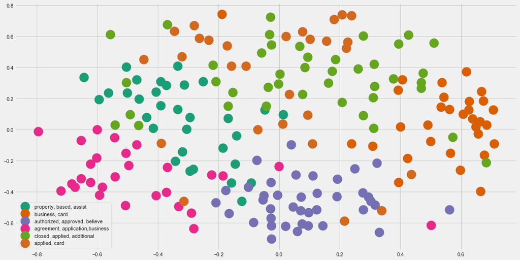

```python
# Set up plot
fig, ax = plt.subplots(figsize=(17, 9)) # set size
for name, group in groups:
    ax.plot(group.x, group.y,
            marker='o',
            linestyle="",
            ms=20,
            label=cluster_names[name],
            color=cluster_colors[name],
            mec='none')

    ax.set_aspect('auto')
    ax.tick_params(axis= 'x',which='both',bottom='off',top='off',labelbottom='off')
    ax.tick_params(axis= 'y',which='both',left='off',top='off',labelleft='off')

ax.legend(numpoints=1)
plt.show()
```

That’s it. We have clustered 200 complaints into 6 groups using K-means clustering. It basically clusters similar kinds of complaints to 6 buckets using TF-IDF. We can also use the word embeddings and solve this to achieve better clusters. 2D graphs provide a good look into the cluster's behavior and if we look, we will see that the same color dots (docs) are located closer to each other.